# STATS 451 Homework 9

Yuzhou Peng

2024-04-18

```r
library(rstan)
batting <- read.csv("C:\\Users\\Penguin\\Desktop\\BattingAverage.csv")
```

```r
rstan_options(auto_write = TRUE)
options(mc.cores = parallel::detectCores())
```

# Problem 1

```r
# Total number of pitchers
sum(batting$PriPos == 'Pitcher')
```

```
## [1] 324
```

```r
# Total number of players
nrow(batting)
```

```
## [1] 948
```

```r
# Median of pitchers-at-bat
pitcher_atbats = batting$AtBats[batting$PriPos == 'Pitcher']
median(pitcher_atbats)
```

```
## [1] 4
```

```r
# Total number of catchers-at-bat
sum(batting$PriPos == 'Catcher')
```

```
## [1] 103
```

```r
# Median of catchers-at-bat
catcher_atbats = batting$AtBats[batting$PriPos == 'Catcher']
median(catcher_atbats)
```

```
## [1] 170
```

```r
#Total number of right fielders
sum(batting$PriPos == 'Right Field')
```

```
## [1] 60
```

```r
# Total number of right fielders-at-bat
Right_Field = batting$AtBats[batting$PriPos == 'Right Field']

# Total number of the rest players
sum(batting$PriPos != 'Right Field' & batting$PriPos != 'Pitcher' & batting$PriPos != 'Catcher')
```

```
## [1] 461
```

```r
median(batting$AtBats[batting$PriPos != 'Right Field' & batting$PriPos != 'Pitcher' & batting$PriPos != 'Catcher'])
```

```
## [1] 227
```

# Problem 2

```r
sum(batting$AtBats[batting$PriPos == 'Pitcher'])
```

```
## [1] 5033
```

```r
sum(batting$AtBats[batting$PriPos == 'Catcher'])
```

```
## [1] 19264
```

Pitchers have lower chance of batting then catcher

# Problem 3

```r
batting <- batting[, colnames(batting) %in% c("Player", "PriPos", "Hits", "AtBats")]
stan_data = list(Nsubj = 948, Ncat = 9, N = batting$AtBats, y = batting$Hits, c = as.numeric(factor(batting$PriPos)))
```

# Problem 4

The stan model code is stored in file “batting_average_model.stan”.

# Problem 5 Run 10000 iterations in total

```r
batting_fit_1 <- stan(file = 'batting_average_model.stan', data = stan_data,
            iter = 10000, chains = 1, core = 4)
```

```
## recompiling to avoid crashing R session
```

```r
print(batting_fit_1, pars = "theta")
```

```
## Inference for Stan model: anon_model.
## 1 chains, each with iter=10000; warmup=5000; thin=1;
## post-warmup draws per chain=5000, total post-warmup draws=5000.
##
##            mean se_mean   sd 2.5%  25%  50%  75% 97.5% n_eff Rhat
## theta[1]   0.13       0 0.03 0.07 0.11 0.13 0.15  0.20  9449    1
## theta[2]   0.25       0 0.02 0.21 0.23 0.25 0.26  0.29 10391    1
## theta[3]   0.25       0 0.03 0.20 0.23 0.25 0.27  0.30  9415    1
## theta[4]   0.23       0 0.01 0.20 0.22 0.23 0.24  0.26 10647    1
## theta[5]   0.25       0 0.03 0.20 0.23 0.25 0.27  0.30 10792    1
## theta[6]   0.13       0 0.03 0.07 0.10 0.13 0.15  0.20  8923    1
## theta[7]   0.13       0 0.03 0.07 0.11 0.13 0.15  0.20  9429    1
## theta[8]   0.24       0 0.03 0.19 0.22 0.24 0.26  0.30  9977    1
## theta[9]   0.27       0 0.02 0.24 0.26 0.27 0.28  0.30 11500    1
## theta[10]  0.28       0 0.02 0.25 0.27 0.28 0.29  0.31 10694    1
## theta[11]  0.13       0 0.03 0.07 0.11 0.13 0.15  0.21  9526    1
## theta[12]  0.25       0 0.02 0.22 0.24 0.25 0.26  0.28 11912    1
## theta[13]  0.24       0 0.02 0.21 0.23 0.24 0.26  0.28  9775    1
## theta[14]  0.24       0 0.03 0.18 0.22 0.24 0.26  0.31 10742    1
## theta[15]  0.25       0 0.03 0.19 0.23 0.25 0.27  0.31 10080    1
## theta[16]  0.23       0 0.02 0.19 0.21 0.23 0.24  0.26  8344    1
## theta[17]  0.28       0 0.02 0.25 0.27 0.28 0.29  0.31 10407    1
## theta[18]  0.25       0 0.02 0.20 0.23 0.25 0.26  0.29 12832    1
## theta[19]  0.28       0 0.01 0.25 0.27 0.28 0.29  0.31 11180    1
## theta[20]  0.13       0 0.03 0.07 0.10 0.12 0.15  0.20  9139    1
## theta[21]  0.24       0 0.02 0.20 0.22 0.24 0.25  0.28 10768    1
## theta[22]  0.26       0 0.02 0.23 0.25 0.26 0.28  0.30 11054    1
## theta[23]  0.13       0 0.03 0.07 0.10 0.12 0.15  0.20  9319    1
## theta[24]  0.14       0 0.03 0.09 0.12 0.13 0.15  0.20 11152    1
## theta[25]  0.24       0 0.03 0.19 0.22 0.24 0.26  0.29 10059    1
## theta[26]  0.24       0 0.02 0.21 0.23 0.24 0.25  0.28 11013    1
## theta[27]  0.14       0 0.04 0.08 0.11 0.13 0.16  0.21  7721    1
## theta[28]  0.25       0 0.02 0.22 0.24 0.25 0.26  0.28 13353    1
## theta[29]  0.13       0 0.03 0.07 0.11 0.13 0.15  0.20  7657    1
## theta[30]  0.28       0 0.02 0.25 0.27 0.28 0.29  0.31  9004    1
## theta[31]  0.13       0 0.03 0.07 0.11 0.13 0.15  0.20  9608    1
## theta[32]  0.12       0 0.02 0.08 0.11 0.12 0.14  0.17  8715    1
## theta[33]  0.25       0 0.02 0.22 0.24 0.25 0.27  0.29  9396    1
## theta[34]  0.24       0 0.02 0.20 0.22 0.24 0.25  0.29 11677    1
## theta[35]  0.13       0 0.03 0.07 0.10 0.13 0.15  0.21  8545    1
```

[output cut: 903 more lines]

```
## theta[939] 0.26       0 0.02 0.23 0.25 0.26 0.27  0.29 11766    1
## theta[940] 0.28       0 0.02 0.24 0.27 0.28 0.30  0.33  9747    1
## theta[941] 0.24       0 0.03 0.19 0.22 0.24 0.26  0.30  9147    1
## theta[942] 0.27       0 0.02 0.24 0.26 0.27 0.28  0.30 11693    1
## theta[943] 0.14       0 0.03 0.09 0.12 0.14 0.16  0.21  9061    1
## theta[944] 0.14       0 0.03 0.08 0.11 0.13 0.16  0.21  8161    1
## theta[945] 0.28       0 0.02 0.24 0.26 0.28 0.29  0.31 11203    1
## theta[946] 0.15       0 0.03 0.10 0.13 0.15 0.17  0.21  3908    1
## theta[947] 0.11       0 0.03 0.06 0.09 0.11 0.13  0.16  3107    1
## theta[948] 0.27       0 0.01 0.24 0.26 0.27 0.28  0.29 10922    1
##
## Samples were drawn using NUTS(diag_e) at Fri Apr 19 17:50:20 2024.
## For each parameter, n_eff is a crude measure of effective sample size,
## and Rhat is the potential scale reduction factor on split chains (at
## convergence, Rhat=1).
```

# Problem 6 Run 32000 iterations to obtain at least 10000 effective sample size

```r
batting_fit_2 <- stan(file = 'batting_average_model.stan', data = stan_data,
            iter = 8000, chains = 4, core = 4)
print(batting_fit_2, pars = "theta")
```

```
## Inference for Stan model: anon_model.
## 4 chains, each with iter=8000; warmup=4000; thin=1;
## post-warmup draws per chain=4000, total post-warmup draws=16000.
##
##            mean se_mean   sd 2.5%  25%  50%  75% 97.5% n_eff Rhat
## theta[1]   0.13       0 0.03 0.07 0.11 0.13 0.15  0.21 29983    1
## theta[2]   0.25       0 0.02 0.21 0.23 0.25 0.26  0.29 33930    1
## theta[3]   0.25       0 0.02 0.21 0.24 0.25 0.27  0.30 32414    1
## theta[4]   0.23       0 0.01 0.20 0.22 0.23 0.24  0.26 28876    1
## theta[5]   0.25       0 0.02 0.20 0.23 0.25 0.27  0.30 29749    1
## theta[6]   0.13       0 0.04 0.07 0.10 0.13 0.15  0.21 25381    1
## theta[7]   0.13       0 0.04 0.07 0.10 0.13 0.15  0.21 28533    1
## theta[8]   0.24       0 0.03 0.19 0.22 0.24 0.26  0.30 28768    1
## theta[9]   0.27       0 0.02 0.24 0.26 0.27 0.28  0.30 36078    1
## theta[10]  0.28       0 0.02 0.25 0.27 0.28 0.29  0.31 31607    1
## theta[11]  0.13       0 0.04 0.07 0.10 0.13 0.15  0.21 28046    1
## theta[12]  0.25       0 0.02 0.22 0.24 0.25 0.26  0.28 31031    1
## theta[13]  0.25       0 0.02 0.21 0.23 0.25 0.26  0.28 34997    1
## theta[14]  0.24       0 0.03 0.18 0.22 0.24 0.26  0.31 31925    1
## theta[15]  0.25       0 0.03 0.19 0.23 0.25 0.27  0.31 32036    1
## theta[16]  0.23       0 0.02 0.19 0.22 0.23 0.24  0.26 25153    1
## theta[17]  0.28       0 0.02 0.25 0.27 0.28 0.29  0.31 30428    1
## theta[18]  0.25       0 0.02 0.20 0.23 0.25 0.26  0.29 28576    1
## theta[19]  0.28       0 0.02 0.25 0.27 0.28 0.29  0.31 31273    1
## theta[20]  0.13       0 0.03 0.06 0.10 0.12 0.15  0.20 25161    1
## theta[21]  0.24       0 0.02 0.20 0.22 0.24 0.25  0.27 36901    1
## theta[22]  0.27       0 0.02 0.23 0.25 0.26 0.28  0.30 36268    1
## theta[23]  0.13       0 0.03 0.06 0.10 0.12 0.15  0.20 28564    1
## theta[24]  0.14       0 0.03 0.09 0.12 0.13 0.15  0.19 31073    1
## theta[25]  0.24       0 0.03 0.19 0.23 0.24 0.26  0.29 31521    1
## theta[26]  0.24       0 0.02 0.21 0.23 0.24 0.25  0.28 34887    1
## theta[27]  0.14       0 0.04 0.08 0.11 0.13 0.16  0.22 28587    1
## theta[28]  0.25       0 0.02 0.22 0.24 0.25 0.26  0.28 32749    1
## theta[29]  0.13       0 0.04 0.07 0.10 0.13 0.15  0.21 27556    1
## theta[30]  0.28       0 0.02 0.25 0.27 0.28 0.29  0.31 29139    1
## theta[31]  0.13       0 0.04 0.07 0.10 0.13 0.15  0.21 25541    1
## theta[32]  0.12       0 0.03 0.08 0.11 0.12 0.14  0.18 28098    1
## theta[33]  0.25       0 0.02 0.22 0.24 0.25 0.27  0.29 29910    1
## theta[34]  0.24       0 0.02 0.20 0.22 0.24 0.25  0.29 34930    1
## theta[35]  0.13       0 0.04 0.07 0.10 0.13 0.15  0.21 27635    1
```

[output cut: 903 more lines]

```
## theta[939] 0.26       0 0.02 0.23 0.25 0.26 0.27  0.29 32096    1
## theta[940] 0.28       0 0.02 0.24 0.27 0.28 0.30  0.33 28422    1
## theta[941] 0.24       0 0.03 0.19 0.22 0.24 0.26  0.31 29908    1
## theta[942] 0.27       0 0.02 0.24 0.26 0.27 0.28  0.30 32209    1
## theta[943] 0.14       0 0.03 0.09 0.12 0.14 0.16  0.21 20840    1
## theta[944] 0.14       0 0.04 0.07 0.11 0.13 0.16  0.21 26889    1
## theta[945] 0.28       0 0.02 0.24 0.26 0.28 0.29  0.31 33698    1
## theta[946] 0.15       0 0.03 0.10 0.13 0.15 0.17  0.22 13067    1
## theta[947] 0.11       0 0.03 0.06 0.09 0.11 0.13  0.17 13861    1
## theta[948] 0.27       0 0.01 0.24 0.26 0.27 0.28  0.30 33415    1
##
## Samples were drawn using NUTS(diag_e) at Fri Apr 19 17:56:37 2024.
## For each parameter, n_eff is a crude measure of effective sample size,
## and Rhat is the potential scale reduction factor on split chains (at
## convergence, Rhat=1).
```

Among the first key parameters, the smallest `n_eff` comes from theta[76] which is still larger than 10000.

# Problem 7

```r
print(batting_fit_2, pars = "theta")
```

```
## Inference for Stan model: anon_model.
## 4 chains, each with iter=8000; warmup=4000; thin=1;
## post-warmup draws per chain=4000, total post-warmup draws=16000.
##
##            mean se_mean   sd 2.5%  25%  50%  75% 97.5% n_eff Rhat
## theta[1]   0.13       0 0.03 0.07 0.11 0.13 0.15  0.21 29983    1
## theta[2]   0.25       0 0.02 0.21 0.23 0.25 0.26  0.29 33930    1
## theta[3]   0.25       0 0.02 0.21 0.24 0.25 0.27  0.30 32414    1
## theta[4]   0.23       0 0.01 0.20 0.22 0.23 0.24  0.26 28876    1
## theta[5]   0.25       0 0.02 0.20 0.23 0.25 0.27  0.30 29749    1
## theta[6]   0.13       0 0.04 0.07 0.10 0.13 0.15  0.21 25381    1
## theta[7]   0.13       0 0.04 0.07 0.10 0.13 0.15  0.21 28533    1
## theta[8]   0.24       0 0.03 0.19 0.22 0.24 0.26  0.30 28768    1
## theta[9]   0.27       0 0.02 0.24 0.26 0.27 0.28  0.30 36078    1
## theta[10]  0.28       0 0.02 0.25 0.27 0.28 0.29  0.31 31607    1
## theta[11]  0.13       0 0.04 0.07 0.10 0.13 0.15  0.21 28046    1
## theta[12]  0.25       0 0.02 0.22 0.24 0.25 0.26  0.28 31031    1
## theta[13]  0.25       0 0.02 0.21 0.23 0.25 0.26  0.28 34997    1
## theta[14]  0.24       0 0.03 0.18 0.22 0.24 0.26  0.31 31925    1
## theta[15]  0.25       0 0.03 0.19 0.23 0.25 0.27  0.31 32036    1
## theta[16]  0.23       0 0.02 0.19 0.22 0.23 0.24  0.26 25153    1
## theta[17]  0.28       0 0.02 0.25 0.27 0.28 0.29  0.31 30428    1
## theta[18]  0.25       0 0.02 0.20 0.23 0.25 0.26  0.29 28576    1
## theta[19]  0.28       0 0.02 0.25 0.27 0.28 0.29  0.31 31273    1
## theta[20]  0.13       0 0.03 0.06 0.10 0.12 0.15  0.20 25161    1
## theta[21]  0.24       0 0.02 0.20 0.22 0.24 0.25  0.27 36901    1
## theta[22]  0.27       0 0.02 0.23 0.25 0.26 0.28  0.30 36268    1
## theta[23]  0.13       0 0.03 0.06 0.10 0.12 0.15  0.20 28564    1
## theta[24]  0.14       0 0.03 0.09 0.12 0.13 0.15  0.19 31073    1
## theta[25]  0.24       0 0.03 0.19 0.23 0.24 0.26  0.29 31521    1
## theta[26]  0.24       0 0.02 0.21 0.23 0.24 0.25  0.28 34887    1
## theta[27]  0.14       0 0.04 0.08 0.11 0.13 0.16  0.22 28587    1
## theta[28]  0.25       0 0.02 0.22 0.24 0.25 0.26  0.28 32749    1
## theta[29]  0.13       0 0.04 0.07 0.10 0.13 0.15  0.21 27556    1
## theta[30]  0.28       0 0.02 0.25 0.27 0.28 0.29  0.31 29139    1
## theta[31]  0.13       0 0.04 0.07 0.10 0.13 0.15  0.21 25541    1
## theta[32]  0.12       0 0.03 0.08 0.11 0.12 0.14  0.18 28098    1
## theta[33]  0.25       0 0.02 0.22 0.24 0.25 0.27  0.29 29910    1
## theta[34]  0.24       0 0.02 0.20 0.22 0.24 0.25  0.29 34930    1
## theta[35]  0.13       0 0.04 0.07 0.10 0.13 0.15  0.21 27635    1
```

[output cut: 903 more lines]

```
## theta[939] 0.26       0 0.02 0.23 0.25 0.26 0.27  0.29 32096    1
## theta[940] 0.28       0 0.02 0.24 0.27 0.28 0.30  0.33 28422    1
## theta[941] 0.24       0 0.03 0.19 0.22 0.24 0.26  0.31 29908    1
## theta[942] 0.27       0 0.02 0.24 0.26 0.27 0.28  0.30 32209    1
## theta[943] 0.14       0 0.03 0.09 0.12 0.14 0.16  0.21 20840    1
## theta[944] 0.14       0 0.04 0.07 0.11 0.13 0.16  0.21 26889    1
## theta[945] 0.28       0 0.02 0.24 0.26 0.28 0.29  0.31 33698    1
## theta[946] 0.15       0 0.03 0.10 0.13 0.15 0.17  0.22 13067    1
## theta[947] 0.11       0 0.03 0.06 0.09 0.11 0.13  0.17 13861    1
## theta[948] 0.27       0 0.01 0.24 0.26 0.27 0.28  0.30 33415    1
##
## Samples were drawn using NUTS(diag_e) at Fri Apr 19 17:56:37 2024.
## For each parameter, n_eff is a crude measure of effective sample size,
## and Rhat is the potential scale reduction factor on split chains (at
## convergence, Rhat=1).
```

# Problem 8

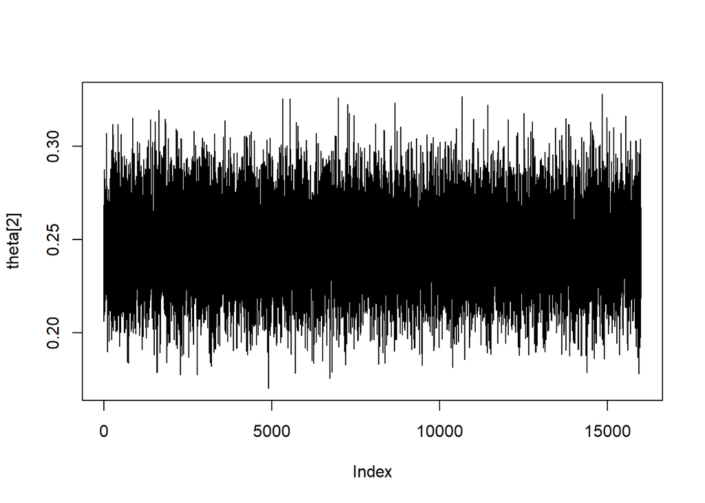

```r
batting_sample <-  rstan::extract(batting_fit_2)
batting_sample_theta <- batting_sample$theta

#Visualize theta[2] as example.
plot(batting_sample_theta[,2], type = "l", ylab = "theta[2]")
```

The plot of the Marcov chain showed above follows a stationary distribution and mixes well, indicating good convergence.

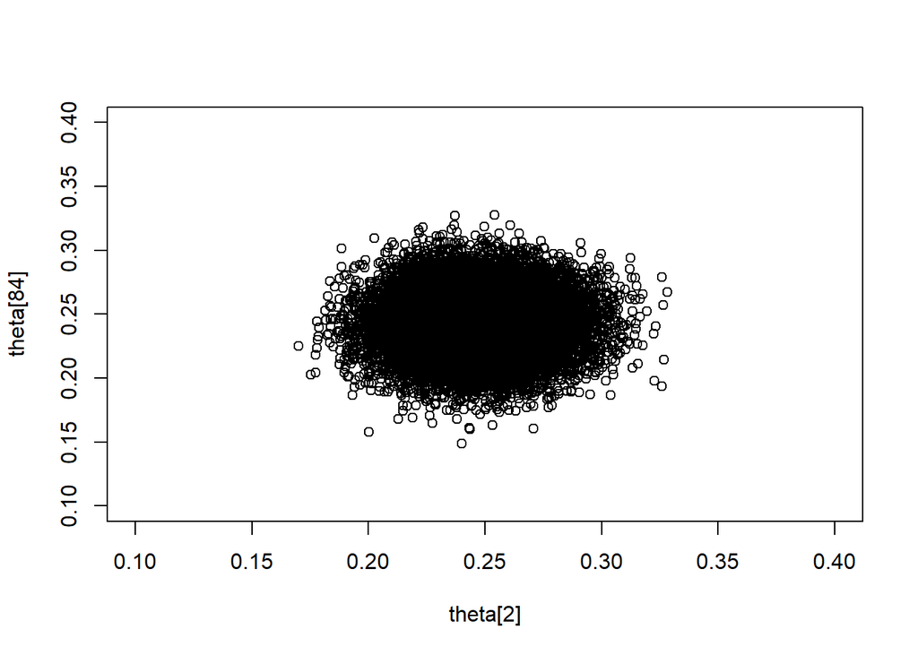

```r
# Example of joint distribution of two parameters
plot(batting_sample_theta[,2], batting_sample_theta[,84], xlim = c(0.1, 0.4), ylim = c(0.1, 0.4), xlab = "theta[2]", ylab = "theta[84]")
```

```r
# Correlation calculation

cor(batting_sample_theta[,2], batting_sample_theta[,84])
```

```
## [1] 0.004359213
```

# Problem 9

```r
# Choose player 6 and 8
player_ability_diff <- batting_sample_theta[,8] - batting_sample_theta[,6]

summary(player_ability_diff)
```

```
##     Min.  1st Qu.   Median     Mean  3rd Qu.     Max.
## -0.08762  0.08350  0.11398  0.11231  0.14310  0.29141
```

```r
quantile(player_ability_diff, c(0.025, 0.975))
```

```
##       2.5%      97.5%
## 0.02026174 0.19545974
```

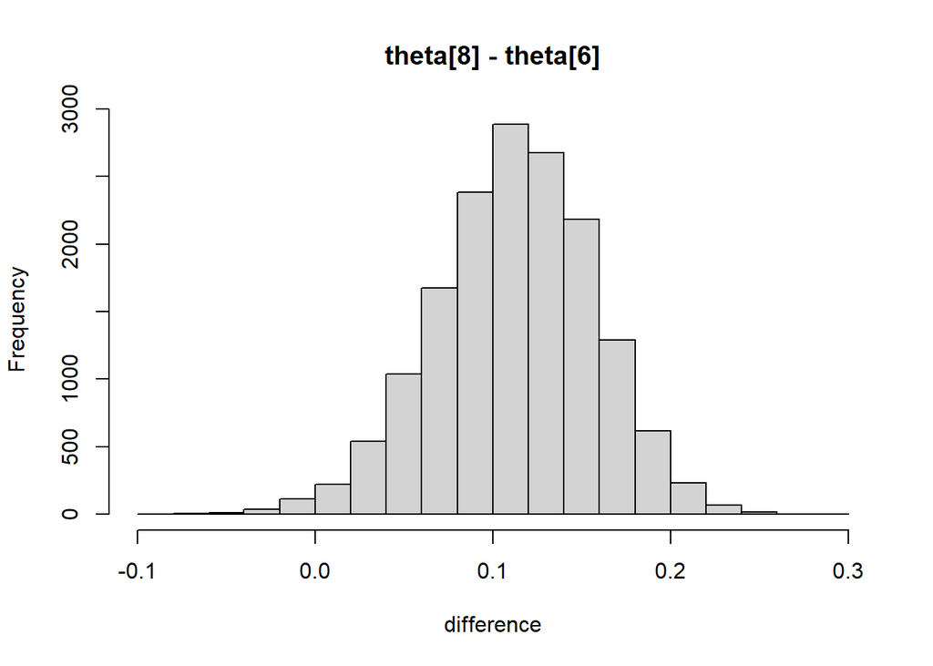

```r
hist(player_ability_diff, main = "theta[8] - theta[6]", xlab = "difference")
```

A sample 95% CI suggest that there is enough evidence to claim player 8 has better batting ability than player 6.  
The mean difference of batting rate is around 0.11

# Problem 10

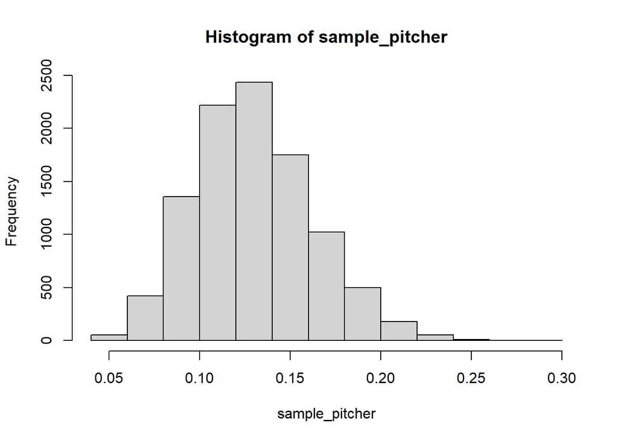

```r
# Compare Pitcher and Left Fielder (category 7 and 6)
# theta[i] is assumed to follow beta(alpha[i], beta[i]), we use the sample mean to approximate true parameters.
batting_sample_alpha7 <-  mean(batting_sample$alpha[,7])
batting_sample_alpha6 <-  mean(batting_sample$alpha[,6])
batting_sample_betac6 <-  mean(batting_sample$beta[,6])
batting_sample_betac7 <-  mean(batting_sample$beta[,7])

# Draw sample from the two distribution

sample_pitcher <- rbeta(10000, shape1 = batting_sample_alpha7, shape2 = batting_sample_betac7)
sample_left <- rbeta(10000, shape1 = batting_sample_alpha6, shape2 = batting_sample_betac6)
position_ability_diff <- sample_left - sample_pitcher

hist(sample_pitcher)
```

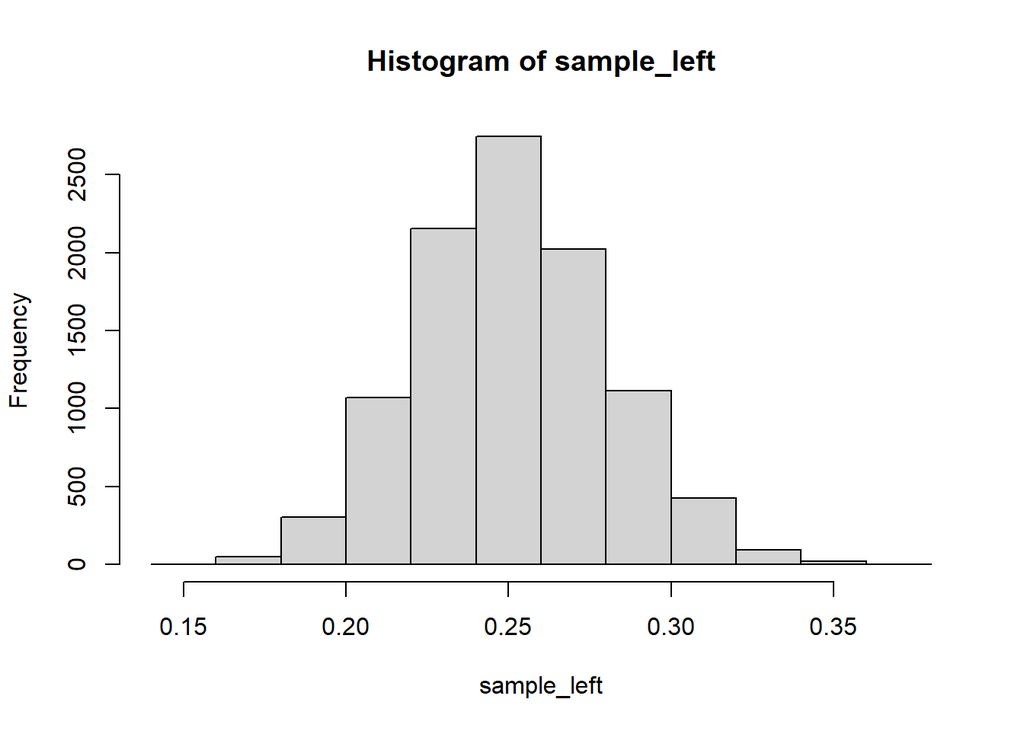

```r
hist(sample_left)
```

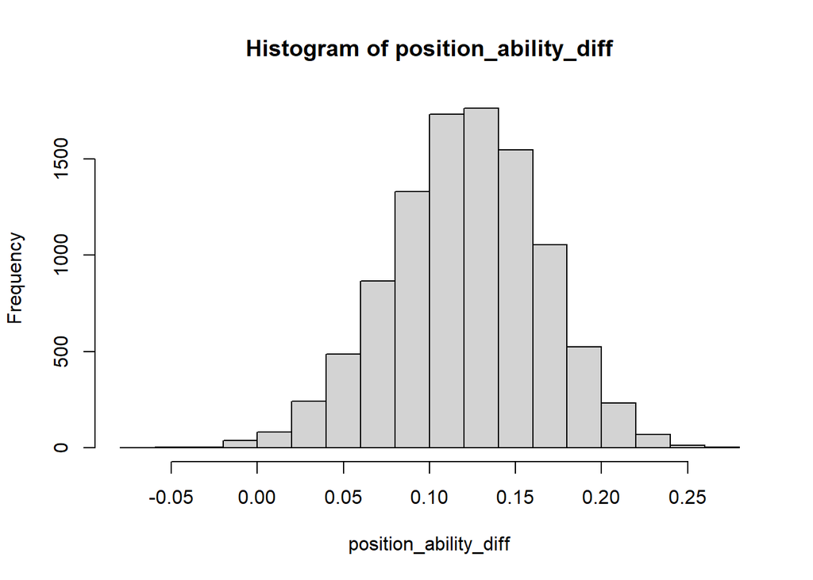

```r
hist(position_ability_diff)
```

```r
summary(position_ability_diff)
```

```
##     Min.  1st Qu.   Median     Mean  3rd Qu.     Max.
## -0.06914  0.09274  0.12244  0.12129  0.15156  0.27967
```

```r
quantile(position_ability_diff, c(0.025, 0.975))
```

```
##       2.5%      97.5%
## 0.03149495 0.20461383
```

A sample 95% CI suggest that there is enough evidence to claim Left Fielders have better batting ability Pitchers.  
The mean difference of batting rate is around 0.12.

# Problem 11

```r
batting_fit_modified <- stan(file = 'parameter_modified.stan', data = stan_data,
            iter = 2500, chains = 4, core = 4)
```

```
## recompiling to avoid crashing R session
```

```r
print(batting_fit_modified, par= "theta")
```

```
## Inference for Stan model: anon_model.
## 4 chains, each with iter=2500; warmup=1250; thin=1;
## post-warmup draws per chain=1250, total post-warmup draws=5000.
##
##            mean se_mean   sd 2.5%  25%  50%  75% 97.5% n_eff Rhat
## theta[1]   0.14       0 0.08 0.02 0.08 0.13 0.19  0.34  7751    1
## theta[2]   0.24       0 0.03 0.19 0.22 0.24 0.26  0.30  8463    1
## theta[3]   0.26       0 0.05 0.17 0.22 0.26 0.29  0.36  7323    1
## theta[4]   0.23       0 0.02 0.19 0.21 0.23 0.24  0.26  8063    1
## theta[5]   0.25       0 0.04 0.16 0.22 0.24 0.28  0.33  6452    1
## theta[6]   0.13       0 0.10 0.01 0.05 0.11 0.18  0.37  6853    1
## theta[7]   0.13       0 0.10 0.01 0.05 0.11 0.18  0.38  7164    1
## theta[8]   0.15       0 0.07 0.04 0.10 0.14 0.19  0.30  6789    1
## theta[9]   0.27       0 0.02 0.24 0.26 0.27 0.29  0.31  7632    1
## theta[10]  0.29       0 0.02 0.25 0.28 0.29 0.30  0.33  7327    1
## theta[11]  0.13       0 0.10 0.01 0.05 0.11 0.18  0.37  7623    1
## theta[12]  0.24       0 0.02 0.21 0.23 0.24 0.26  0.28  8641    1
## theta[13]  0.24       0 0.03 0.19 0.22 0.24 0.26  0.29  7173    1
## theta[14]  0.25       0 0.09 0.10 0.18 0.24 0.31  0.45  6422    1
## theta[15]  0.20       0 0.09 0.06 0.13 0.19 0.25  0.41  7102    1
## theta[16]  0.21       0 0.02 0.17 0.20 0.21 0.23  0.25  7400    1
## theta[17]  0.29       0 0.02 0.25 0.27 0.29 0.30  0.32  7152    1
## theta[18]  0.23       0 0.03 0.17 0.21 0.23 0.25  0.30  7774    1
## theta[19]  0.29       0 0.02 0.25 0.28 0.29 0.30  0.33  7931    1
## theta[20]  0.11       0 0.08 0.01 0.05 0.09 0.15  0.32  7215    1
## theta[21]  0.23       0 0.02 0.19 0.22 0.23 0.25  0.28  6086    1
## theta[22]  0.27       0 0.02 0.22 0.25 0.27 0.29  0.32  7098    1
## theta[23]  0.11       0 0.08 0.01 0.04 0.09 0.15  0.32  7584    1
## theta[24]  0.14       0 0.04 0.07 0.11 0.14 0.17  0.24  8344    1
## theta[25]  0.23       0 0.04 0.15 0.20 0.22 0.25  0.31  7483    1
## theta[26]  0.24       0 0.02 0.20 0.23 0.24 0.26  0.29  8493    1
## theta[27]  0.19       0 0.11 0.03 0.10 0.17 0.25  0.46  7450    1
## theta[28]  0.25       0 0.02 0.22 0.24 0.25 0.26  0.29  6790    1
## theta[29]  0.13       0 0.10 0.01 0.05 0.11 0.19  0.38  6395    1
## theta[30]  0.29       0 0.02 0.25 0.28 0.29 0.30  0.33  7433    1
## theta[31]  0.13       0 0.10 0.01 0.05 0.11 0.18  0.38  7551    1
## theta[32]  0.12       0 0.04 0.05 0.09 0.11 0.14  0.20  6874    1
## theta[33]  0.24       0 0.03 0.18 0.22 0.24 0.26  0.30  7008    1
## theta[34]  0.24       0 0.03 0.18 0.22 0.24 0.26  0.30  7107    1
## theta[35]  0.13       0 0.10 0.01 0.05 0.11 0.18  0.38  7336    1
```

[output cut: 903 more lines]

```
## theta[939] 0.27       0 0.02 0.23 0.25 0.27 0.28  0.30  8269    1
## theta[940] 0.31       0 0.03 0.25 0.29 0.31 0.34  0.38  7505    1
## theta[941] 0.18       0 0.08 0.05 0.12 0.17 0.23  0.37  6841    1
## theta[942] 0.28       0 0.02 0.24 0.26 0.28 0.29  0.31  7881    1
## theta[943] 0.17       0 0.06 0.08 0.13 0.17 0.21  0.29  7208    1
## theta[944] 0.17       0 0.10 0.03 0.10 0.16 0.23  0.40  7800    1
## theta[945] 0.28       0 0.02 0.25 0.27 0.28 0.29  0.32  8914    1
## theta[946] 0.19       0 0.05 0.10 0.15 0.18 0.22  0.29  7636    1
## theta[947] 0.09       0 0.03 0.03 0.06 0.08 0.11  0.16  7324    1
## theta[948] 0.27       0 0.02 0.23 0.26 0.27 0.28  0.31  6329    1
##
## Samples were drawn using NUTS(diag_e) at Fri Apr 19 18:00:09 2024.
## For each parameter, n_eff is a crude measure of effective sample size,
## and Rhat is the potential scale reduction factor on split chains (at
## convergence, Rhat=1).
```

# Problem 12

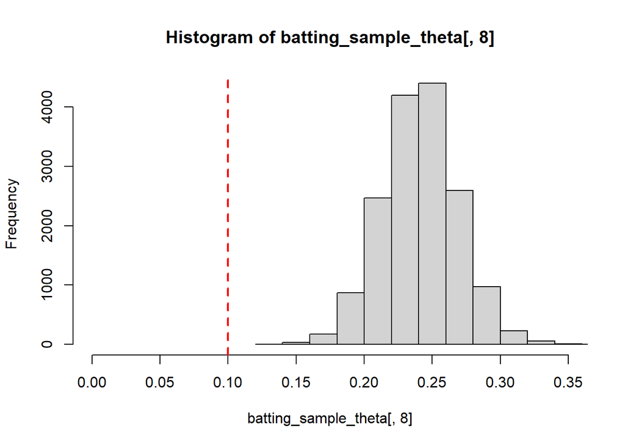

```r
# Analyse player 8 as an example

hist(batting_sample_theta[,8], xlim = c(0, 0.35))
abline(v=0.1, col="red", lwd=2, lty=2)
```

The red dotted vertical line is theta[8] estimated MLE.  
The histogram shows the sample of estimated theta[8], which is shrunk away by hierarchical model.